# Praktikum 6 Anreg

# Library

```r
library(readxl)   # untuk membaca data
library(GGally)   # untuk menghasilkan matriks hubungan antarpeubah
library(corrplot) # untuk menghasilkan matriks korelasi
library(dplyr)    # untuk manipulasi data
library(car)      # untuk memeriksa multikolinearitas
library(stargazer) # untuk menampilkan hasil perbandingan regresi
library(lmtest)   # untuk uji kehomogenan ragam sisaan dan saling bebas
library(olsrr)    # untuk pemeriksaan amatan tidak biasa
```

# Data

```r
dt_raw <- read_xlsx("C:\\Users\\najwe\\OneDrive\\Dokumen\\SEMESTER 4\\ANREG\\Data Prak Anreg.xlsx", sheet="Data Gabungan Anreg")

# Rename kolom
colnames(dt_raw) <- c("Provinsi", "PBP", "IDL", "IKU", "IKA", "SL", "PBS", "TPR")

dt_raw
```

```
## # A tibble: 38 × 8
##    Provinsi               PBP   IDL   IKU   IKA    SL   PBS   TPR
##    <chr>                <dbl> <dbl> <dbl> <dbl> <dbl> <dbl> <dbl>
##  1 Aceh                   0.6  24.8  90.9  61.3  78.8  29.4  28.3
##  2 Sumatera Utara         0.5  41.0  90.9  60.3  84.2  18.9  26.2
##  3 Sumatera Barat         0.4  39.1  90.5  57.0  71.0  23.6  30.1
##  4 Riau                   0.2  45.0  90.9  50.8  84.6  13.6  27.4
##  5 Jambi                  0.5  53.0  90.6  46.1  83.0  13.5  27.9
##  6 Sumatera Selatan       0.3  54.3  87.8  58.2  80.5  20.3  30.3
##  7 Bengkulu               1.1  71.4  92.5  49.0  80.3  20.2  31.5
##  8 Lampung                0.8  73.8  88.0  55.4  84.6  14.9  33.8
##  9 Kep. Bangka Belitung   0.4  72.5  90.2  57.4  93.2  20.6  26.3
## 10 Kepulauan Riau         0.9  70.8  90.1  54.9  91.1  16.8  24.7
## # ℹ 28 more rows
```

```r
str(dt_raw)
```

```
## tibble [38 × 8] (S3: tbl_df/tbl/data.frame)
##  $ Provinsi: chr [1:38] "Aceh" "Sumatera Utara" "Sumatera Barat" "Riau" ...
##  $ PBP     : num [1:38] 0.6 0.5 0.4 0.2 0.5 0.3 1.1 0.8 0.4 0.9 ...
##  $ IDL     : num [1:38] 24.8 41 39.1 45 53 ...
##  $ IKU     : num [1:38] 90.9 90.9 90.5 90.9 90.6 ...
##  $ IKA     : num [1:38] 61.3 60.3 57 50.8 46.1 ...
##  $ SL      : num [1:38] 78.8 84.2 71 84.6 83 ...
##  $ PBS     : num [1:38] 29.4 18.9 23.6 13.6 13.5 20.3 20.2 14.9 20.6 16.8 ...
##  $ TPR     : num [1:38] 28.3 26.2 30.1 27.4 27.9 ...
```

```r
summary(dt_raw)
```

```
##    Provinsi              PBP             IDL             IKU
##  Length:38          Min.   :0.200   Min.   :24.79   Min.   :66.67
##  Class :character   1st Qu.:0.525   1st Qu.:52.73   1st Qu.:89.76
##  Mode  :character   Median :0.950   Median :65.11   Median :91.20
##                     Mean   :1.137   Mean   :60.72   Mean   :90.24
##                     3rd Qu.:1.375   3rd Qu.:71.25   3rd Qu.:93.30
##                     Max.   :5.300   Max.   :84.50   Max.   :97.68
##
##       IKA              SL             PBS             TPR
##  Min.   :40.28   Min.   :43.00   Min.   : 7.20   Min.   :18.14
##  1st Qu.:52.72   1st Qu.:79.11   1st Qu.:19.23   1st Qu.:24.61
##  Median :55.75   Median :83.38   Median :23.65   Median :26.62
##  Mean   :55.29   Mean   :82.57   Mean   :23.57   Mean   :26.79
##  3rd Qu.:58.90   3rd Qu.:86.28   3rd Qu.:27.35   3rd Qu.:28.77
##  Max.   :64.67   Max.   :96.42   Max.   :39.40   Max.   :33.75
##                  NA's   :4                       NA's   :4
```

Data yang digunakan adalah data tingkat provinsi di Indonesia tahun 2023 dengan 1 peubah respon yaitu **Prevalensi Balita Pneumonia (PBP)** dan 6 peubah penjelas:

- **IDL**: Persentase Anak Umur 12–23 Bulan yang Menerima Imunisasi Dasar Lengkap
- **IKU**: Indeks Kualitas Udara
- **IKA**: Indeks Kualitas Air
- **SL**: Persentase Rumah Tangga yang Memiliki Akses terhadap Sanitasi Layak
- **PBS**: Prevalensi Balita Stunting
- **TPR**: Total Jumlah Perokok di atas 15 Tahun

Terdapat 4 provinsi pemekaran baru (Papua Barat Daya, Papua Selatan, Papua Tengah, Papua Pegunungan) yang tidak memiliki data lengkap pada peubah SL dan TPR, sehingga analisis dilakukan pada 34 provinsi dengan data lengkap.

```r
dt <- dt_raw %>%
  select(-Provinsi) %>%
  na.omit()
```

# Eksplorasi Data

## Peubah Respon

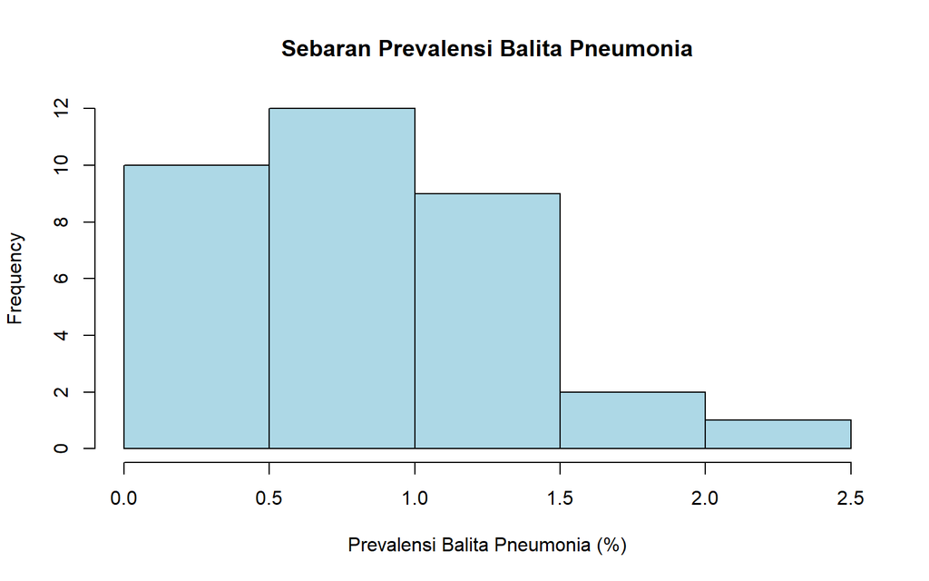

```r
hist(dt$PBP, main = "Sebaran Prevalensi Balita Pneumonia",
     xlab = "Prevalensi Balita Pneumonia (%)", col = "lightblue")
```

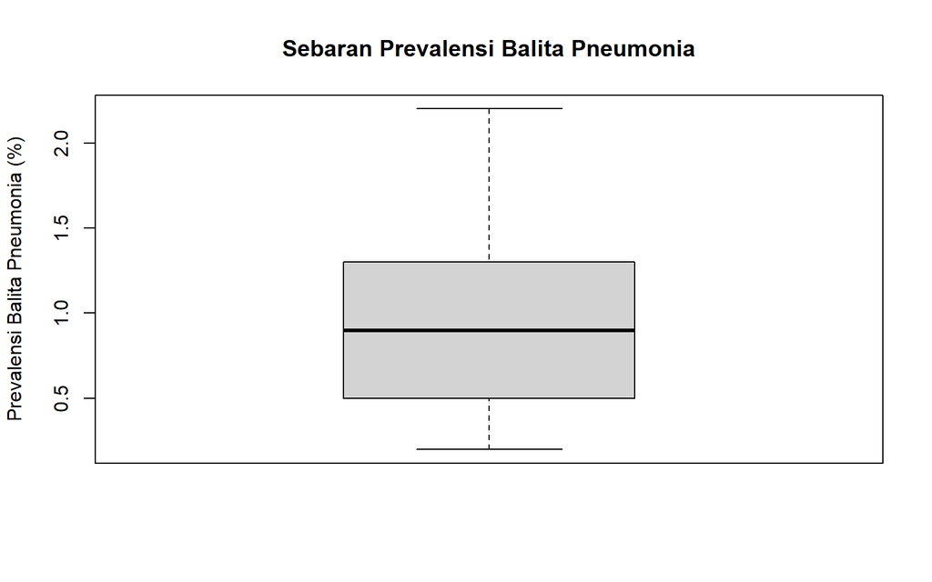

```r
boxplot(dt$PBP, main = "Sebaran Prevalensi Balita Pneumonia",
        ylab = "Prevalensi Balita Pneumonia (%)")
```

## Peubah Penjelas vs Peubah Respon

### IDL

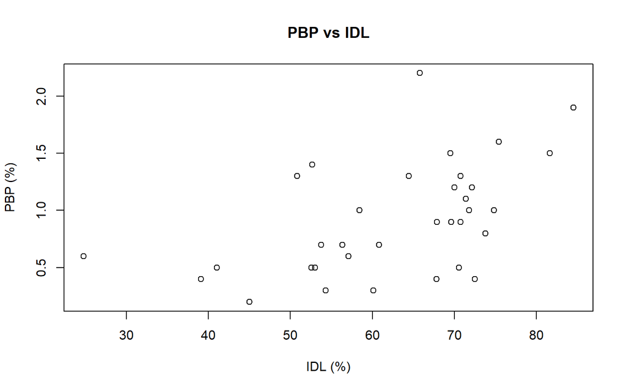

```r
plot(dt$IDL, dt$PBP,
     xlab = "IDL (%)", ylab = "PBP (%)",
     main = "PBP vs IDL")
```

Hubungan antara IDL dan PBP cenderung positif dan relatif linear. Semakin tinggi cakupan imunisasi dasar lengkap, prevalensi pneumonia balita cenderung meningkat — ini bisa mencerminkan bahwa daerah dengan imunisasi tinggi memiliki populasi balita yang lebih padat dan terpantau.

### IKU

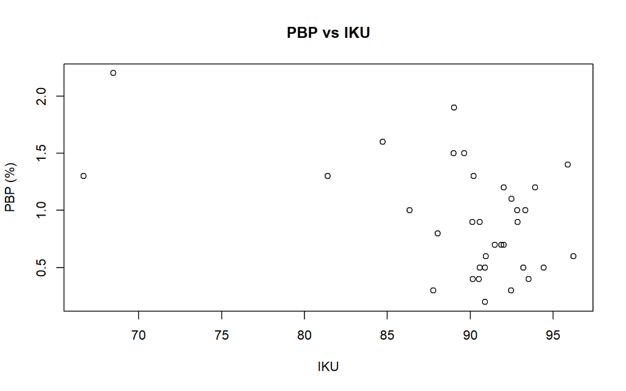

```r
plot(dt$IKU, dt$PBP,
     xlab = "IKU", ylab = "PBP (%)",
     main = "PBP vs IKU")
```

### IKA

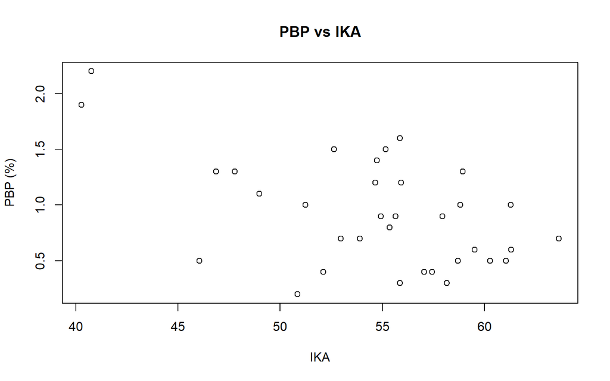

```r
plot(dt$IKA, dt$PBP,
     xlab = "IKA", ylab = "PBP (%)",
     main = "PBP vs IKA")
```

Hubungan antara IKA dan PBP cenderung negatif, kualitas air yang lebih baik berkaitan dengan prevalensi pneumonia yang lebih rendah. Pola hubungan relatif linear.

### SL

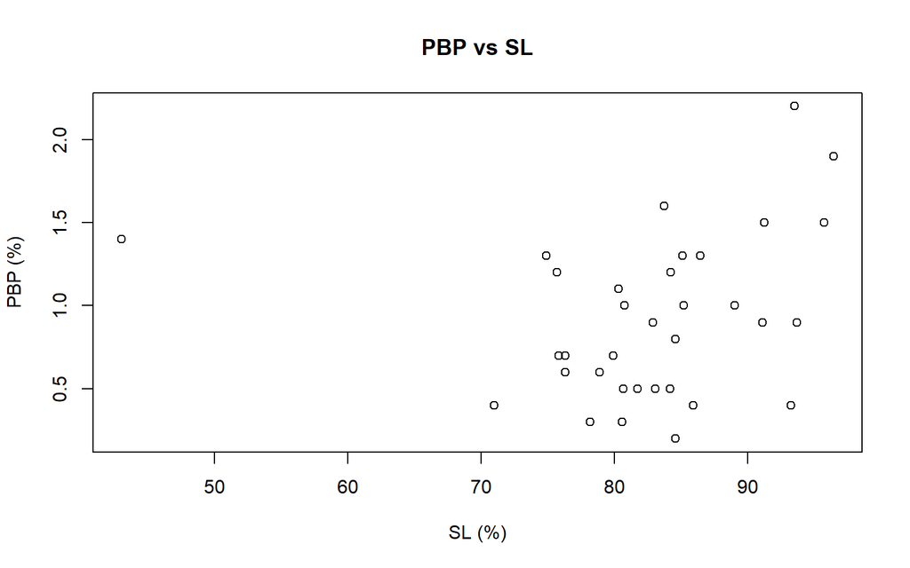

```r
plot(dt$SL, dt$PBP,
     xlab = "SL (%)", ylab = "PBP (%)",
     main = "PBP vs SL")
```

Hubungan antara SL dan PBP tidak terlalu jelas, korelasinya lemah (r = 0.18). Amatan DKI Jakarta dan DI Yogyakarta berada di ujung kanan dengan nilai sanitasi layak tertinggi.

### PBS

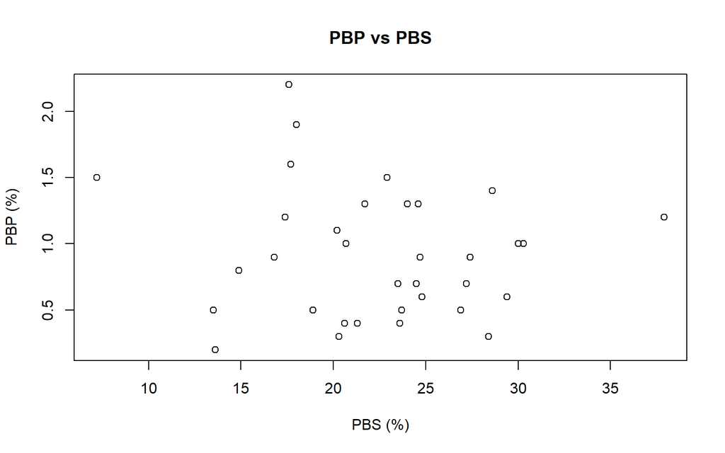

```r
plot(dt$PBS, dt$PBP,
     xlab = "PBS (%)", ylab = "PBP (%)",
     main = "PBP vs PBS")
```

Hubungan antara PBS dan PBP juga lemah (r = −0.11). Tidak ada pola yang jelas antara prevalensi stunting dan pneumonia pada tingkat provinsi.

### TPR

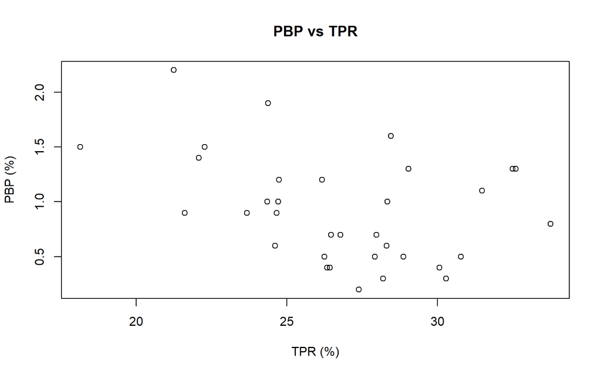

```r
plot(dt$TPR, dt$PBP,
     xlab = "TPR (%)", ylab = "PBP (%)",
     main = "PBP vs TPR")
```

Hubungan antara TPR dan PBP cenderung negatif (r = −0.38). Daerah dengan persentase perokok lebih tinggi cenderung memiliki prevalensi pneumonia balita lebih rendah — temuan ini mungkin bersifat confounding dan perlu kehati-hatian dalam interpretasi.

## Korelasi

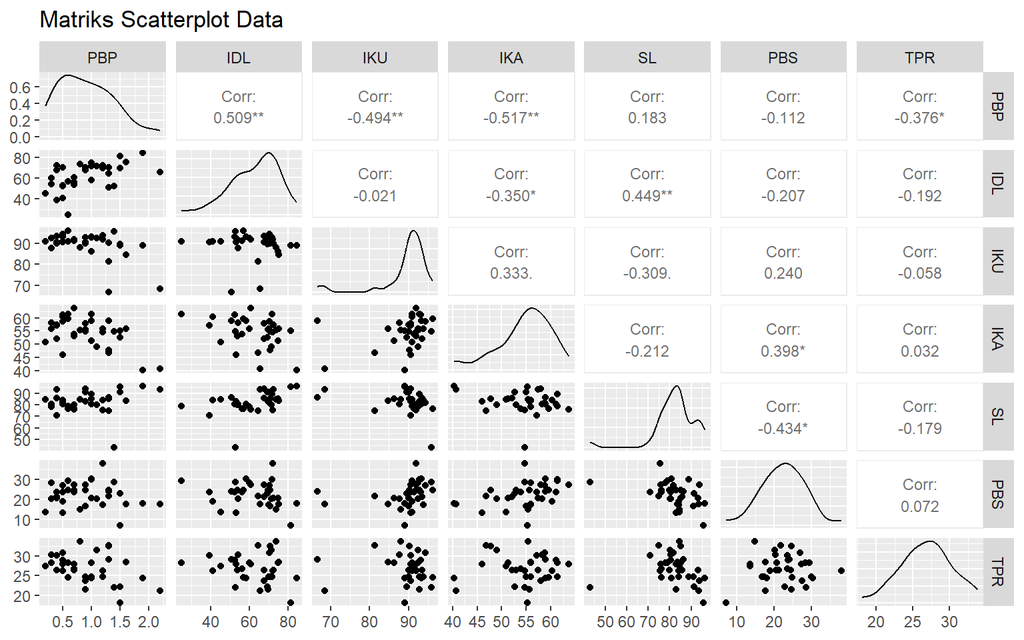

```r
ggpairs(dt,
        upper = list(continuous = wrap('cor', size = 3)),
        title = "Matriks Scatterplot Data")
```

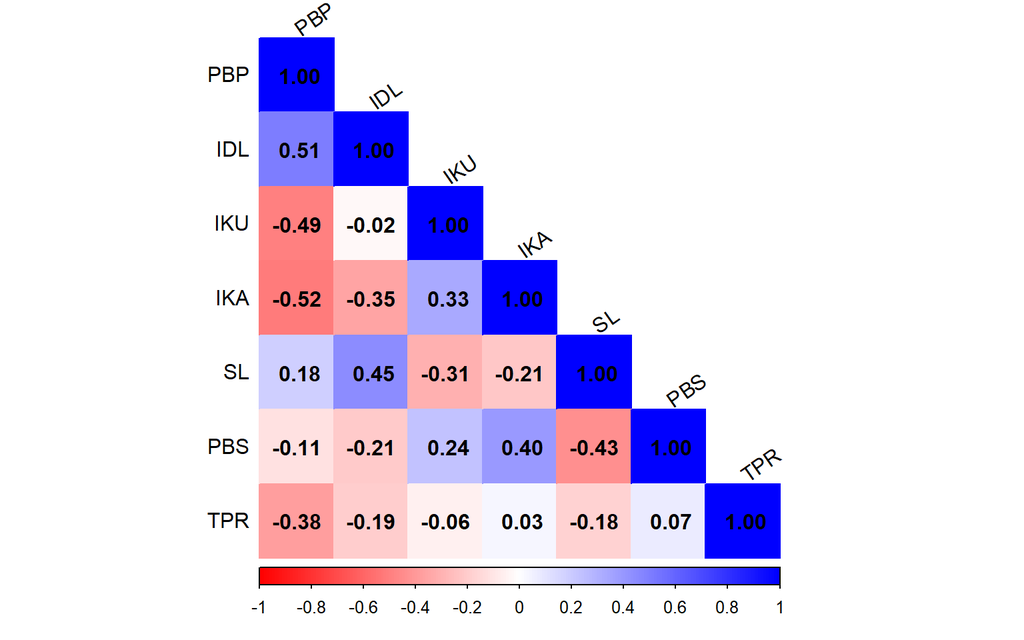

```r
cor_matrix <- cor(dt, use = "complete.obs")

corrplot(cor_matrix, method = "color", type = "lower",
         col = colorRampPalette(c("red", "white", "blue"))(200),
         addCoef.col = "black", tl.col = "black", tl.srt = 35)
```

Hasil matriks scatter plot dan korelasi menunjukkan bahwa peubah respon PBP memiliki hubungan **positif** dengan IDL (r = 0.51) dan hubungan **negatif** dengan IKU (r = −0.49), IKA (r = −0.52), dan TPR (r = −0.38). Peubah SL dan PBS memiliki korelasi yang lebih lemah terhadap PBP.

Korelasi antar peubah penjelas relatif rendah (tidak ada yang melebihi 0.5 secara absolut), sehingga potensi multikolinearitas tidak terlalu mengkhawatirkan. Namun tetap perlu diperiksa secara formal.

# Pemodelan

```r
model1 <- lm(formula = PBP ~ ., data = dt)
summary(model1)
```

```
##
## Call:
## lm(formula = PBP ~ ., data = dt)
##
## Residuals:
##      Min       1Q   Median       3Q      Max
## -0.48324 -0.14139 -0.02309  0.16477  0.52194
##
## Coefficients:
##              Estimate Std. Error t value Pr(>|t|)
## (Intercept)  6.895086   1.210740   5.695 4.74e-06 ***
## IDL          0.017949   0.004707   3.814 0.000723 ***
## IKU         -0.040473   0.008956  -4.519 0.000111 ***
## IKA         -0.023833   0.010881  -2.190 0.037306 *
## SL          -0.013183   0.006795  -1.940 0.062881 .
## PBS          0.011055   0.009920   1.114 0.274918
## TPR         -0.049660   0.014483  -3.429 0.001960 **
## ---
## Signif. codes:  0 '***' 0.001 '**' 0.01 '*' 0.05 '.' 0.1 ' ' 1
##
## Residual standard error: 0.2857 on 27 degrees of freedom
## Multiple R-squared:  0.7166, Adjusted R-squared:  0.6537
## F-statistic: 11.38 on 6 and 27 DF,  p-value: 2.462e-06
```

Persamaan yang terbentuk adalah:

$$\hat{PBP} = 6.8951 + 0.0179\,IDL -
0.0405\,IKU - 0.0238\,IKA - 0.0132\,SL + 0.0111\,PBS -
0.0497\,TPR$$

# Pemeriksaan Multikolinearitas

## Perubahan Peubah

```r
mod1 <- lm(PBP ~ IDL, dt)
mod2 <- lm(PBP ~ IDL + IKU, dt)
mod3 <- lm(PBP ~ IDL + IKU + IKA, dt)
mod4 <- lm(PBP ~ IDL + IKU + IKA + SL, dt)
mod5 <- lm(PBP ~ IDL + IKU + IKA + SL + PBS, dt)
mod6 <- lm(PBP ~ IDL + IKU + IKA + SL + PBS + TPR, dt)

stargazer(mod1, mod2, mod3, mod4, mod5, mod6,
          type = "text", single.row = TRUE)
```

```
##
## ============================================================================================================================================================
##                                                                               Dependent variable:
##                     ----------------------------------------------------------------------------------------------------------------------------------------
##                                                                                       PBP
##                              (1)                    (2)                    (3)                    (4)                    (5)                   (6)
## ------------------------------------------------------------------------------------------------------------------------------------------------------------
## IDL                    0.019*** (0.006)       0.019*** (0.005)       0.016*** (0.005)       0.020*** (0.005)      0.020*** (0.006)       0.018*** (0.005)
## IKU                                          -0.037*** (0.010)      -0.031*** (0.010)      -0.038*** (0.010)      -0.038*** (0.010)     -0.040*** (0.009)
## IKA                                                                   -0.021 (0.012)         -0.019 (0.012)        -0.023* (0.013)       -0.024** (0.011)
## SL                                                                                          -0.013* (0.007)        -0.010 (0.008)        -0.013* (0.007)
## PBS                                                                                                                 0.011 (0.012)         0.011 (0.010)
## TPR                                                                                                                                     -0.050*** (0.014)
## Constant                -0.278 (0.366)        3.074*** (0.939)       3.862*** (1.030)       5.154*** (1.231)      4.938*** (1.256)       6.895*** (1.211)
## ------------------------------------------------------------------------------------------------------------------------------------------------------------
## Observations                  34                     34                     34                     34                    34                     34
## R2                          0.259                  0.492                  0.535                  0.581                  0.593                 0.717
## Adjusted R2                 0.236                  0.460                  0.489                  0.523                  0.521                 0.654
## Residual Std. Error    0.424 (df = 32)        0.357 (df = 31)        0.347 (df = 30)        0.335 (df = 29)        0.336 (df = 28)       0.286 (df = 27)
## F Statistic         11.182*** (df = 1; 32) 15.042*** (df = 2; 31) 11.511*** (df = 3; 30) 10.052*** (df = 4; 29) 8.168*** (df = 5; 28) 11.381*** (df = 6; 27)
## ============================================================================================================================================================
## Note:                                                                                                                            *p<0.1; **p<0.05; ***p<0.01
```

Dugaan parameter tidak mengalami perubahan tanda yang drastis saat peubah ditambahkan satu per satu. Hal ini mendukung indikasi bahwa tidak ada multikolinearitas yang serius pada model.

## Perubahan Banyak Data

```r
mod_full  <- lm(PBP ~ ., dt)
mod_half  <- lm(PBP ~ ., dt[1:17, ])

stargazer(summary(mod_full)$coefficients, summary(mod_half)$coefficients,
          type = "text",
          font.size = "small")
```

```
##
## ===================================================
##             Estimate Std. Error t value Pr(> | t| )
## ---------------------------------------------------
## (Intercept)  6.895     1.211     5.695    0.00000
## IDL          0.018     0.005     3.814     0.001
## IKU          -0.040    0.009    -4.519    0.0001
## IKA          -0.024    0.011    -2.190     0.037
## SL           -0.013    0.007    -1.940     0.063
## PBS          0.011     0.010     1.114     0.275
## TPR          -0.050    0.014    -3.429     0.002
## ---------------------------------------------------
##
## ===================================================
##             Estimate Std. Error t value Pr(> | t| )
## ---------------------------------------------------
## (Intercept)  7.843     2.949     2.660     0.024
## IDL          0.023     0.008     2.987     0.014
## IKU          -0.035    0.012    -2.984     0.014
## IKA          -0.023    0.015    -1.588     0.143
## SL           -0.028    0.024    -1.180     0.265
## PBS          0.032     0.022     1.439     0.181
## TPR          -0.080    0.037    -2.176     0.055
## ---------------------------------------------------
```

Terdapat sedikit perubahan pada dugaan parameter ketika jumlah amatan berbeda, tetapi tidak ada perubahan tanda yang fundamental. Ini mengkonfirmasi bahwa multikolinearitas bukan masalah utama pada data ini.

## Akar Ciri

```r
x_mat <- dt[-1]  # hapus kolom PBP
r_mat <- cor(x_mat)
(ev <- eigen(r_mat)$values)
```

```
## [1] 2.2351018 1.1778472 0.8219316 0.7446459 0.6990532 0.3214202
```

```r
# Simultan
if ((max(ev) / min(ev)) <= 100) {
  cat("Tidak ada multikolinearitas\n")
} else if ((max(ev) / min(ev)) > 100 & (max(ev) / min(ev)) <= 1000) {
  cat("Ada multikolinearitas yang lemah\n")
} else {
  cat("Ada multikolinearitas yang kuat\n")
}
```

```
## Tidak ada multikolinearitas
```

```r
# Parsial
if (all((max(ev) / ev) <= 1000)) {
  cat("Tidak ada multikolinearitas\n")
} else {
  cat("Ada multikolinearitas pada peubah penjelas ke:", which((max(ev) / ev) > 1000), "\n")
}
```

```
## Tidak ada multikolinearitas
```

## Nilai VIF

```r
vif(model1)
```

```
##      IDL      IKU      IKA       SL      PBS      TPR
## 1.486577 1.292486 1.470256 1.670573 1.415466 1.062318
```

Hasil pemeriksaan dengan akar ciri menyatakan **tidak ada multikolinearitas** karena nilai max/min eigenvalue = 6.95, jauh di bawah 100. Nilai VIF seluruh peubah juga berada di bawah 5, mengkonfirmasi tidak ada multikolinearitas yang serius. Meskipun demikian, karena peubah **SL** memiliki VIF tertinggi (1.671) dan tidak signifikan dalam model, pada analisis selanjutnya akan dicoba pemodelan dengan menghapus peubah SL untuk menyederhanakan model.

# Pemodelan Penyisihan Peubah

```r
model2 <- lm(PBP ~ IDL + IKU + IKA + PBS + TPR, data = dt)
summary(model2)
```

```
##
## Call:
## lm(formula = PBP ~ IDL + IKU + IKA + PBS + TPR, data = dt)
##
## Residuals:
##      Min       1Q   Median       3Q      Max
## -0.54916 -0.18239 -0.00296  0.17596  0.52849
##
## Coefficients:
##              Estimate Std. Error t value Pr(>|t|)
## (Intercept)  5.512841   1.026095   5.373    1e-05 ***
## IDL          0.013963   0.004439   3.146  0.00390 **
## IKU         -0.034972   0.008904  -3.927  0.00051 ***
## IKA         -0.027511   0.011231  -2.450  0.02081 *
## PBS          0.018169   0.009662   1.880  0.07049 .
## TPR         -0.046245   0.015068  -3.069  0.00473 **
## ---
## Signif. codes:  0 '***' 0.001 '**' 0.01 '*' 0.05 '.' 0.1 ' ' 1
##
## Residual standard error: 0.2994 on 28 degrees of freedom
## Multiple R-squared:  0.6771, Adjusted R-squared:  0.6195
## F-statistic: 11.75 on 5 and 28 DF,  p-value: 3.497e-06
```

Persamaan yang terbentuk adalah:

$$\hat{PBP} = 5.5128 + 0.0140\,IDL -
0.0350\,IKU - 0.0275\,IKA + 0.0182\,PBS - 0.0462\,TPR$$

## Nilai VIF

```r
vif(model2)
```

```
##      IDL      IKU      IKA      PBS      TPR
## 1.203267 1.162902 1.425631 1.222100 1.046626
```

Model hasil reduksi peubah menunjukkan bahwa semua nilai VIF < 5 sehingga dinyatakan tidak terjadi multikolinearitas. Perlu dilanjutkan dengan uji asumsi sisaan dan pemeriksaan amatan tidak biasa.

# Pengujian Asumsi

## Eksplorasi Grafik

### Plot Sisaan vs Y Duga

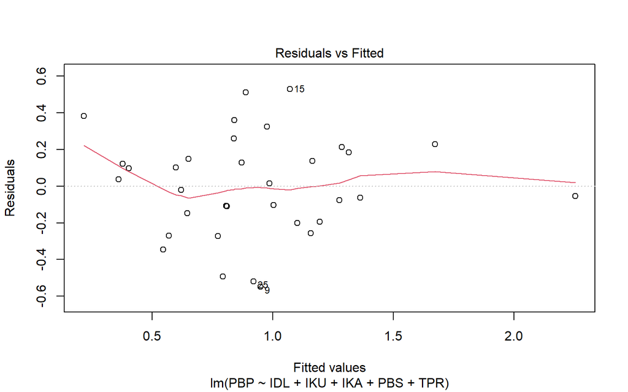

```r
plot(model2, 1)
```

Sisaan tersebar di sekitar 0 dengan lebar pita yang relatif merata untuk setiap nilai dugaan, mengindikasikan nilai harapan sisaan mendekati nol dan ragam sisaan relatif homogen. Tidak terdapat pola yang jelas seperti corong atau kurva.

### Plot Sisaan vs Urutan

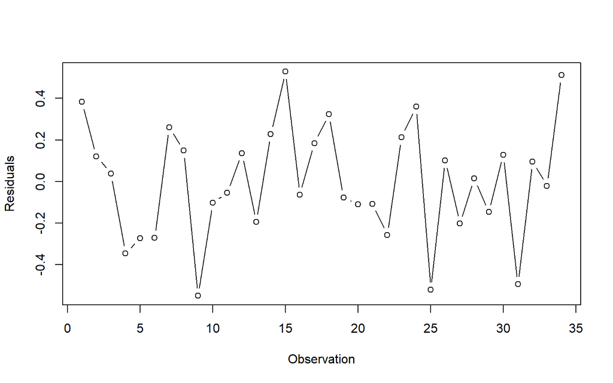

```r
plot(x = 1:nrow(dt),
     y = model2$residuals,
     type = 'b',
     ylab = "Residuals",
     xlab = "Observation")
```

Tebaran tidak berpola secara sistematis, mengindikasikan sisaan saling bebas. Tidak ditemukan pola autokorelasi yang jelas.

### QQ Plot

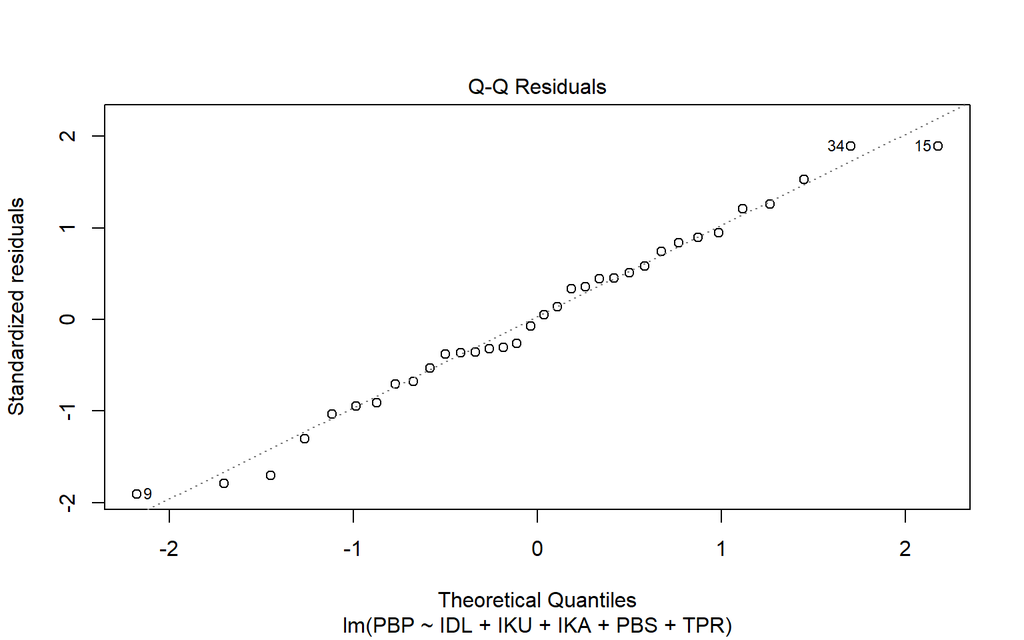

```r
plot(model2, 2)
```

Sebagian besar amatan mengikuti garis diagonal, meskipun terdapat sedikit penyimpangan di ekor distribusi. Perlu dikonfirmasi melalui uji formal.

## Uji Formal

### Nilai Harapan Sisaan Sama dengan Nol

```r
t.test(model2$residuals, mu = 0, conf.level = 0.95)
```

```
##
##  One Sample t-test
##
## data:  model2$residuals
## t = -2.1145e-16, df = 33, p-value = 1
## alternative hypothesis: true mean is not equal to 0
## 95 percent confidence interval:
##  -0.09623498  0.09623498
## sample estimates:
##     mean of x
## -1.000177e-17
```

Nilai p pada uji t sama dengan 1 yang lebih besar dari alpha 5%, sehingga dinyatakan asumsi nilai harapan sisaan sama dengan nol **terpenuhi**.

### Ragam Sisaan Homogen

```r
bptest(model2)
```

```
##
##  studentized Breusch-Pagan test
##
## data:  model2
## BP = 1.588, df = 5, p-value = 0.9027
```

Nilai p pada uji Breusch-Pagan lebih besar dari alpha 5%, sehingga dinyatakan asumsi ragam sisaan homogen **terpenuhi**.

### Sisaan Saling Bebas

```r
dwtest(model2)
```

```
##
##  Durbin-Watson test
##
## data:  model2
## DW = 1.9577, p-value = 0.3291
## alternative hypothesis: true autocorrelation is greater than 0
```

Nilai p pada uji Durbin-Watson lebih besar dari alpha 5%, sehingga dinyatakan asumsi sisaan saling bebas **terpenuhi**.

### Normalitas Sisaan

```r
shapiro.test(model2$residuals)
```

```
##
##  Shapiro-Wilk normality test
##
## data:  model2$residuals
## W = 0.98297, p-value = 0.8606
```

Nilai p pada uji Shapiro-Wilk lebih besar dari alpha 5%, sehingga dinyatakan asumsi normalitas sisaan **terpenuhi**.

Semua asumsi sisaan terpenuhi, namun masih ada peubah yang tidak signifikan (PBS). Perlu dilakukan pemeriksaan lebih lanjut terhadap kemungkinan adanya amatan tidak biasa yang mempengaruhi model.

# Pemeriksaan Amatan Tidak Biasa

```r
# Menggunakan fungsi
ri_stud   <- rstudent(model2)
ri_stan   <- rstandard(model2)
hii_fungsi <- hatvalues(model2)

# Manual
X_mat       <- model.matrix(model2)
H_mat       <- X_mat %*% solve(t(X_mat) %*% X_mat) %*% t(X_mat)
hii_manual  <- diag(H_mat)
anova_model <- anova(model2)
s_val       <- sqrt(anova_model["Residuals", "Mean Sq"])
ei          <- model2$residuals
ri_manual   <- ei / (s_val * sqrt(1 - hii_manual))

nilai <- data.frame(ri_stud, ri_stan, ri_manual, hii_fungsi, hii_manual)
nilai
```

```
##        ri_stud     ri_stan   ri_manual hii_fungsi hii_manual
## 1   1.56732267  1.52808269  1.52808269 0.29984397 0.29984397
## 2   0.43826855  0.44473172  0.44473172 0.16966106 0.16966106
## 3   0.13512475  0.13755781  0.13755781 0.14343877 0.14343877
## 4  -1.32050391 -1.30330824 -1.30330824 0.21782988 0.21782988
## 5  -1.03551781 -1.03418352 -1.03418352 0.22609410 0.22609410
## 6  -0.94484033 -0.94665554 -0.94665554 0.09290678 0.09290678
## 7   0.94458141  0.94640442  0.94640442 0.15374294 0.15374294
## 8   0.57698766  0.58398617  0.58398617 0.27201783 0.27201783
## 9  -2.00923614 -1.90840225 -1.90840225 0.07641217 0.07641217
## 10 -0.35218549 -0.35782719 -0.35782719 0.08101758 0.08101758
## 11 -0.25903644 -0.26346262 -0.26346262 0.54588522 0.54588522
## 12  0.50213183  0.50897505  0.50897505 0.19885715 0.19885715
## 13 -0.66844864 -0.67515116 -0.67515116 0.07583863 0.07583863
## 14  0.89361436  0.89684648  0.89684648 0.27843515 0.27843515
```

[output cut: 20 more lines]

## Pencilan

```r
absri     <- abs(nilai[, 2])
pencilan  <- which(absri > 2)
pencilan
```

```
## integer(0)
```

Berdasarkan nilai sisaan terstandar, **tidak ditemukan pencilan** (tidak ada |$r_i$| > 2). Namun beberapa amatan mendekati batas, seperti amatan ke-9 (Kep. Bangka Belitung), ke-15 (Jawa Timur), dan ke-34 (Papua) yang memiliki nilai mendekati 1.9.

## Leverage

```r
n_obs     <- nrow(dt)
p_par     <- length(model2$coefficients)
cutoff_lev <- 2 * p_par / n_obs

titik_leverage <- which(hii_fungsi > cutoff_lev)
titik_leverage
```

```
## 11 16 17
## 11 16 17
```

Amatan ke-**11 (DKI Jakarta)**, ke-**16 (Banten)**, dan ke-**17 (Bali)** terdeteksi sebagai titik leverage. Ketiga provinsi ini memiliki karakteristik yang cukup berbeda dari mayoritas provinsi lain, terutama dalam hal kualitas udara (DKI Jakarta) dan indeks sanitasi.

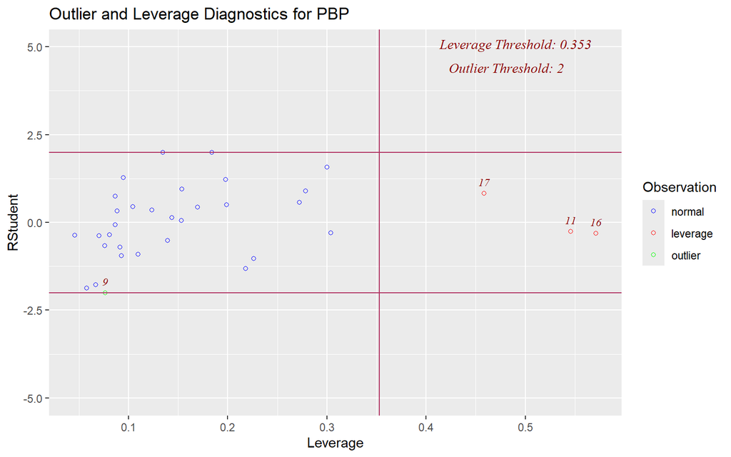

```r
ols_plot_resid_lev(model2)
```

Plot memperlihatkan amatan ke-11 (DKI Jakarta), ke-16 (Banten), dan ke-17 (Bali) sebagai titik leverage. Tidak ada amatan yang sekaligus menjadi pencilan dan leverage (high-leverage outlier).

## Amatan Berpengaruh

### Jarak Cook

```r
di      <- cooks.distance(model2)
f_crit  <- qf(0.05, p_par, n_obs - p_par, lower.tail = FALSE)
data.frame(di, di > f_crit)
```

```
##              di di...f_crit
## 1  1.666644e-01       FALSE
## 2  6.735529e-03       FALSE
## 3  5.281136e-04       FALSE
## 4  7.884230e-02       FALSE
## 5  5.207689e-02       FALSE
## 6  1.529777e-02       FALSE
## 7  2.712034e-02       FALSE
## 8  2.123883e-02       FALSE
## 9  5.021956e-02       FALSE
## 10 1.881341e-03       FALSE
## 11 1.390665e-02       FALSE
## 12 1.071699e-02       FALSE
## 13 6.234383e-03       FALSE
## 14 5.172895e-02       FALSE
```

[output cut: 20 more lines]

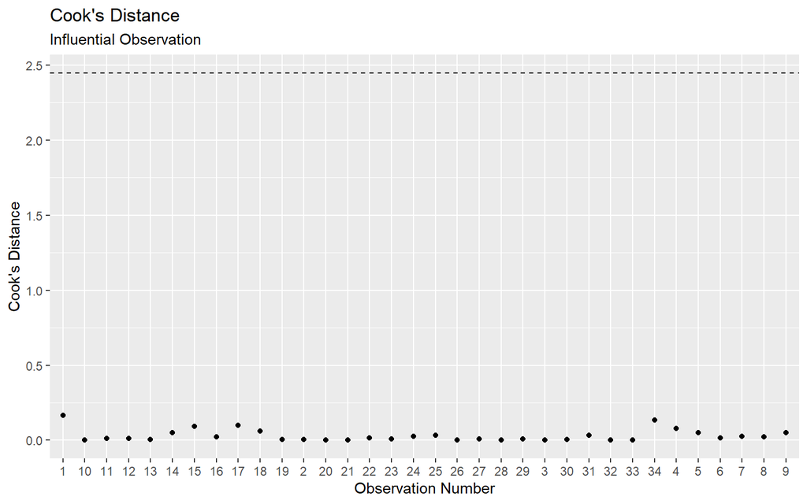

```r
df_cook <- data.frame(obs = names(di), cooks = di)

ggplot(df_cook, aes(y = cooks, x = obs)) +
  geom_point() +
  geom_hline(yintercept = f_crit, linetype = "dashed") +
  labs(title = "Cook's Distance",
       subtitle = "Influential Observation",
       x = "Observation Number",
       y = "Cook's Distance")
```

### DFBETAS

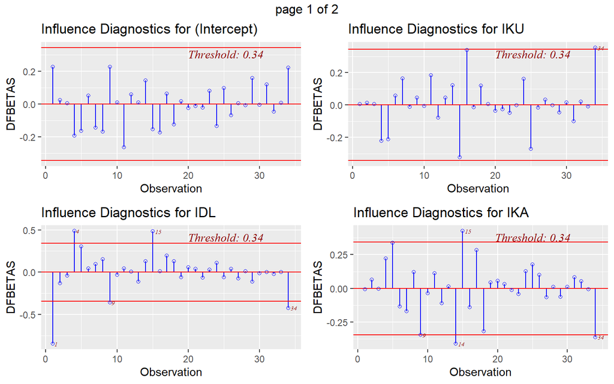

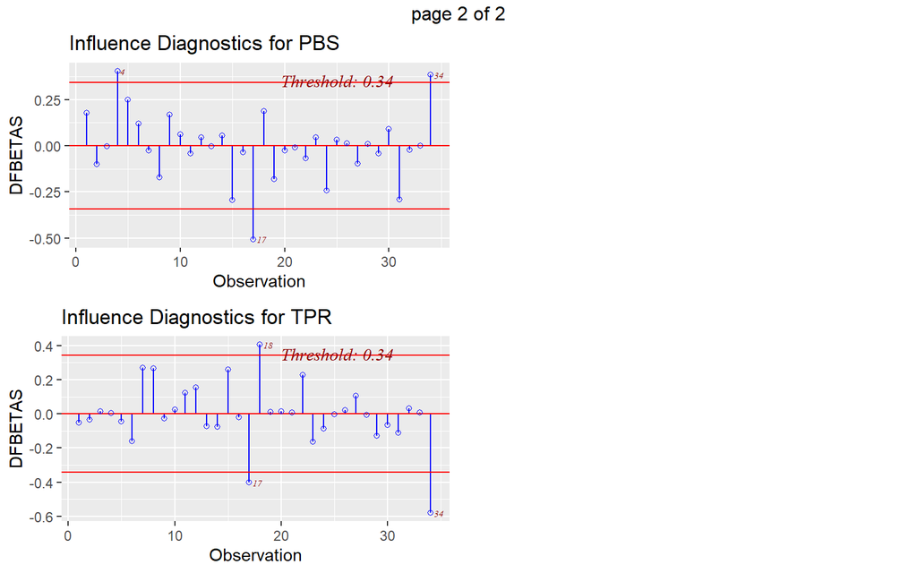

```r
ols_plot_dfbetas(model2)
```

Hasil DFBETAS menunjukkan pengaruh setiap observasi terhadap masing-masing koefisien regresi. DFBETAS mengukur seberapa besar koefisien regresi berubah jika suatu observasi dihapus dari model.

### DFFITS

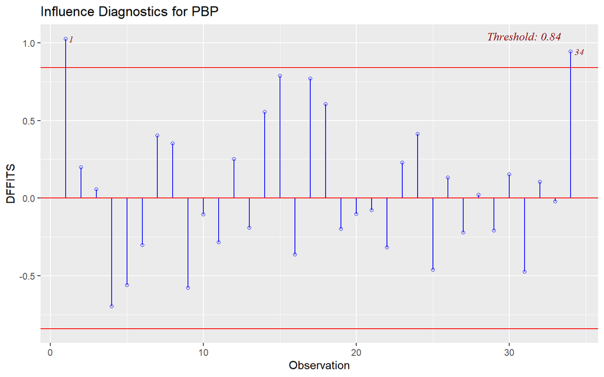

```r
ols_plot_dffits(model2)
```

```r
DFFITSi   <- dffits(model2)
cutoff_df <- 2 * sqrt(p_par / n_obs)

amatan_berpengaruh <- sort(unique(which(abs(DFFITSi) > cutoff_df)))
amatan_berpengaruh
```

```
## [1]  1 34
```